# Exploratory Data Analysis 1 en 2

Deze lesopdracht sluit aan op de volgende datacamp chapters:

- Exploratory Data Analysis 1: https://campus.datacamp.com/courses/exploratory-data-analysis-in-python/getting-to-know-a-dataset?ex=1
- Understanding Data Visualization 1: https://campus.datacamp.com/courses/understanding-data-visualization/visualizing-distributions?ex=1

Dit is een dataset met klantgegevens. De kolommen zijn

- Geboortejaar
- Opleidingsniveau
- Burgelijke staat
- Inkomen
- Aantal kinderen in huis
- Aantal tieners in huis
- Datum waarop een klant voor het eerst klant is geworden
- Aantal dagen sinds laatste aankoop
- Hoeveelheid geld uitgegeven aan wijn in de laatste 2 jaar
- Hoeveelheid geld uitgegeven aan fruit de afgelopen 2 jaar
- Hoeveelheid geld uitgegeven aan vlees de afgelopen 2 jaar
- Hoeveelheid geld uitgegeven aan vis de afgelopen 2 jaar
- Hoeveelheid geld uitgegeven aan snoep de afgelopen 2 jaar
- Hoeveelheid geld uitgegeven aan goud de afgelopen 2 jaar
- Indicator of de persoon de laatste keer mee deed aan een actie.

Machine Learning modellen proberen zaken te voorspellen. Het uiteindelijke doel van deze dataset is voorspellen of klanten gebruik zullen maken van een actie.

Voordat we machine learning toepassen voeren we altijd eerst een Exploratory Data Analysis (EDA) uit.

De eerste stap van een EDA is "Getting to know the data". Dit bestaat uit: 1) Initiële exploratie 2) Data validatie 3) Data samenvatting (summarization)

- Voer onderstaande cel uit om de data te laden.

```python
import pandas as pd
import numpy as np
data = pd.read_excel('shopping.xlsx')
```

### 1 Waarom EDA?

In Datacamp worden twee redenen genoemd voor het uitvoeren van een EDA: 1) Inzicht verkrijgen 2) Hypotheses formuleren

- Bekijk de dataset en schrijf in comments op welke inzichten je uit deze dataset zou kunnen halen.

```python
display(data.head(), data.info())
# Geven mensen met een hoger opleidingsniveau meer uit?
# Zijn mensen met een laag / hoog opleidingsniveau gevoeliger voor acties?
# Geven mensen met een hoog inkomen meer uit? Zijn ze gevoeliger / minder gevoelig voor acties?
# Etc
```

```
<class 'pandas.core.frame.DataFrame'>
RangeIndex: 2240 entries, 0 to 2239
Data columns (total 15 columns):
 #   Column                  Non-Null Count  Dtype
---  ------                  --------------  -----
 0   Year_Birth              2240 non-null   int64
 1   Education               2240 non-null   object
 2   Marital_Status          2240 non-null   object
 3   Income                  2216 non-null   float64
 4   Kidhome                 2240 non-null   int64
 5   Teenhome                2240 non-null   int64
 6   Date_becoming_Customer  2240 non-null   datetime64[ns]
 7   Recency                 2240 non-null   int64
 8   MntWines                2240 non-null   int64
 9   MntFruits               2240 non-null   int64
 10  MntMeatProducts         2240 non-null   int64
 11  MntFishProducts         2240 non-null   int64
 12  MntSweetProducts        2240 non-null   int64
 13  MntGoldProds            2240 non-null   int64
 14  Responded to deal       2240 non-null   int64
dtypes: datetime64[ns](1), float64(1), int64(11), object(2)
memory usage: 262.6+ KB
```

|  | Year_Birth | Education | Marital_Status | Income | Kidhome | Teenhome | Date_becoming_Customer | Recency | MntWines | MntFruits | MntMeatProducts | MntFishProducts | MntSweetProducts | MntGoldProds | Responded to deal |
| --- | --- | --- | --- | --- | --- | --- | --- | --- | --- | --- | --- | --- | --- | --- | --- |
| 0 | 1957 | Graduation | Single | 58138.0 | 0 | 0 | 2012-09-04 | 58 | 635 | 88 | 546 | 172 | 88 | 88 | 1 |
| 1 | 1954 | Graduation | Single | 46344.0 | 1 | 1 | 2014-03-08 | 38 | 11 | 1 | 6 | 2 | 1 | 6 | 0 |
| 2 | 1965 | Graduation | Together | 71613.0 | 0 | 0 | 2013-08-21 | 26 | 426 | 49 | 127 | 111 | 21 | 42 | 0 |
| 3 | 1984 | Graduation | Together | 26646.0 | 1 | 0 | 2014-02-10 | 26 | 11 | 4 | 20 | 10 | 3 | 5 | 0 |
| 4 | 1981 | PhD | Married | 58293.0 | 1 | 0 | 2014-01-19 | 94 | 173 | 43 | 118 | 46 | 27 | 15 | 0 |

```
None
```

### 2 Categorieen

Sommige kolommen bestaan uit numerieke data waarop je rekenkundige bewerkingen kunt uitvoeren. De andere kolommen, behalve 1, bestaan uit categorieen .

- Toon een overzicht van de data types van de kolommen.
- Maak een list van de kolomnamen van kolommen die je als categorieen kunt beschouwen. **Hint:** dit kunnen ook numerieke kolommen zijn.
- Toon van deze kolommen het aantal unieke waardes.
- Verander het datatype van de relevante kolommen in 'category'.

```python
display(data.info(), data.dtypes)

# Categorieen:
# Education
# Marital_Status
# Responded to deal --> deze is minder vanzelfsprekend omdat het een numerieke kolom is. Het is handig om er later mee te kunnen rekenen, dus niet category

cats = ['Education', 'Marital_Status']

for col in cats:
    print(data[col].value_counts())

data[cats] = data[cats].astype('category')
```

```
<class 'pandas.core.frame.DataFrame'>
RangeIndex: 2240 entries, 0 to 2239
Data columns (total 15 columns):
 #   Column                  Non-Null Count  Dtype
---  ------                  --------------  -----
 0   Year_Birth              2240 non-null   int64
 1   Education               2240 non-null   object
 2   Marital_Status          2240 non-null   object
 3   Income                  2216 non-null   float64
 4   Kidhome                 2240 non-null   int64
 5   Teenhome                2240 non-null   int64
 6   Date_becoming_Customer  2240 non-null   datetime64[ns]
 7   Recency                 2240 non-null   int64
 8   MntWines                2240 non-null   int64
 9   MntFruits               2240 non-null   int64
 10  MntMeatProducts         2240 non-null   int64
 11  MntFishProducts         2240 non-null   int64
 12  MntSweetProducts        2240 non-null   int64
 13  MntGoldProds            2240 non-null   int64
 14  Responded to deal       2240 non-null   int64
dtypes: datetime64[ns](1), float64(1), int64(11), object(2)
memory usage: 262.6+ KB
```

```
None
```

```
Year_Birth                         int64
Education                         object
Marital_Status                    object
Income                           float64
Kidhome                            int64
Teenhome                           int64
Date_becoming_Customer    datetime64[ns]
Recency                            int64
MntWines                           int64
MntFruits                          int64
MntMeatProducts                    int64
MntFishProducts                    int64
MntSweetProducts                   int64
MntGoldProds                       int64
Responded to deal                  int64
dtype: object
```

```
Education
Graduation    1127
PhD            486
Master         370
2n Cycle       203
Basic           54
Name: count, dtype: int64
Marital_Status
Married     864
Together    580
Single      480
Divorced    232
Widow        77
Alone         3
Absurd        2
YOLO          2
Name: count, dtype: int64
```

### 3 Numerieke kolommen

- Maak een dataframe met daarin alleen de numerieke kolommen.
- Toon de beschrijvende statistieken van dit dataframe.
- Leg uit wat iedere regel betekent. Geef ook aan hoe deze waardes worden berekend.
- Wat valt je op? Denk hierbij o.a. aan missende waardes. Vergelijk ook de mediaan en het gemiddelde van de kolommen met elkaar.
- Wat is de oorzaak dat soms de mediaan en het gemiddelde sterk verschillen?

```python
num_data = data.select_dtypes('number')
num_data.describe()

# count: aantal regels met een waarde. --> de kolom income heeft missende waardes.
# mean: gemiddelde (optelsom van alle regels / count)
# std: maatstaf voor spreiding van de data. Wortel van de variantie. Komt bij wiskunde nog uitgebreid aan de orde.
    # Variantie = som van het kwadraat van de verschillen ten opzichte van het gemiddelde: https://www.scribbr.nl/statistiek/variantie/
# min: minimum, laagste getal van een kolom
# 25%: 25 procent van de getallen in de kolom zijn lager dan dit getal. 75% is dus hoger.
# 50%: is hetzelfde als mediaan. 50% van de getallen zijn lager dan dit getal. 50% is hoger.
# 75%: 75 procent van de getallen in de kolom zijn lager dan dit getal. 25% is dus hoger.
# max: maximum, hoogste getal van een kolom.

# Opvallend:
# Missende waardes in de 'Income' kolom.
# Kidhome en Teenhome gaan maar tot en met 2.
# Year_Birth: minimum is 1893 (is onwaarschijnlijk)
# Mnt-kolommen: groot verschil tussen gemiddelde en mediaan --> komt vermoedelijk door outliers / scheve verdelingen.
# Maar dit moeten we eerst onderzoeken. --> volgende vragen.
```

|  | Year_Birth | Income | Kidhome | Teenhome | Recency | MntWines | MntFruits | MntMeatProducts | MntFishProducts | MntSweetProducts | MntGoldProds | Responded to deal |
| --- | --- | --- | --- | --- | --- | --- | --- | --- | --- | --- | --- | --- |
| count | 2240.000000 | 2216.000000 | 2240.000000 | 2240.000000 | 2240.000000 | 2240.000000 | 2240.000000 | 2240.000000 | 2240.000000 | 2240.000000 | 2240.000000 | 2240.000000 |
| mean | 1968.805804 | 52247.251354 | 0.444196 | 0.506250 | 49.109375 | 303.935714 | 26.302232 | 166.950000 | 37.525446 | 27.062946 | 44.021875 | 0.149107 |
| std | 11.984069 | 25173.076661 | 0.538398 | 0.544538 | 28.962453 | 336.597393 | 39.773434 | 225.715373 | 54.628979 | 41.280498 | 52.167439 | 0.356274 |
| min | 1893.000000 | 1730.000000 | 0.000000 | 0.000000 | 0.000000 | 0.000000 | 0.000000 | 0.000000 | 0.000000 | 0.000000 | 0.000000 | 0.000000 |
| 25% | 1959.000000 | 35303.000000 | 0.000000 | 0.000000 | 24.000000 | 23.750000 | 1.000000 | 16.000000 | 3.000000 | 1.000000 | 9.000000 | 0.000000 |
| 50% | 1970.000000 | 51381.500000 | 0.000000 | 0.000000 | 49.000000 | 173.500000 | 8.000000 | 67.000000 | 12.000000 | 8.000000 | 24.000000 | 0.000000 |
| 75% | 1977.000000 | 68522.000000 | 1.000000 | 1.000000 | 74.000000 | 504.250000 | 33.000000 | 232.000000 | 50.000000 | 33.000000 | 56.000000 | 0.000000 |
| max | 1996.000000 | 666666.000000 | 2.000000 | 2.000000 | 99.000000 | 1493.000000 | 199.000000 | 1725.000000 | 259.000000 | 263.000000 | 362.000000 | 1.000000 |

### 4 Verdelingen: histogrammen

Bij de vorige vraag konden we nog niet goed verklaren waarom bijvoorbeeld het gemiddelde afwijkt van de mediaan. We hebben daarom inzicht nodig in de verdelingen. Een manier om dit inzicht te krijgen is met een histogram.

- Leg uit wat een histogram is.
- Toon van alle relevante kolommen een histogram.
- Beschrijf wat je ziet in ieder histogram. Lijkt het op een normale verdeling? Zie je skewness? Zijn er outliers?
- Klopt je vermoeden over de verschillen tussen mediaan en gemiddelde?

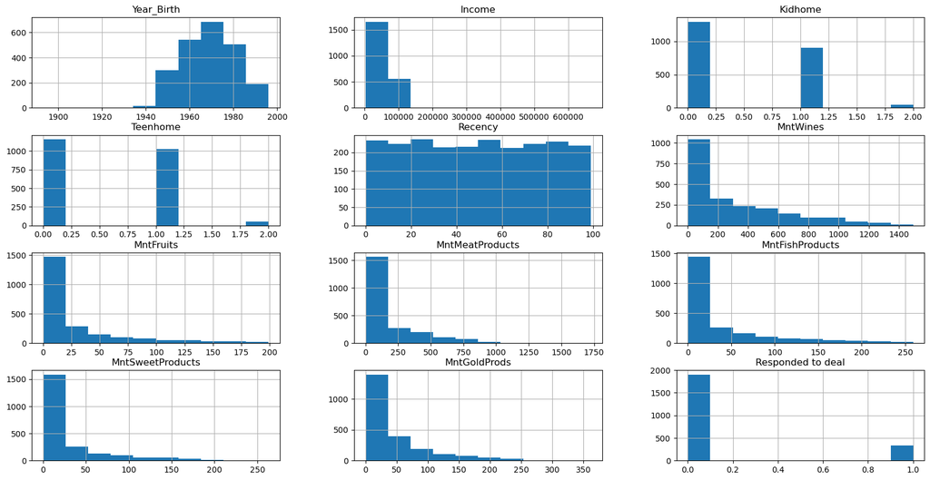

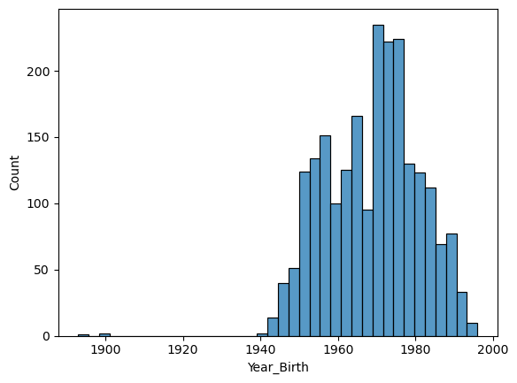

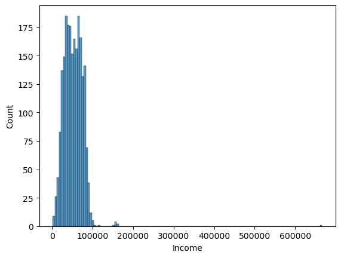

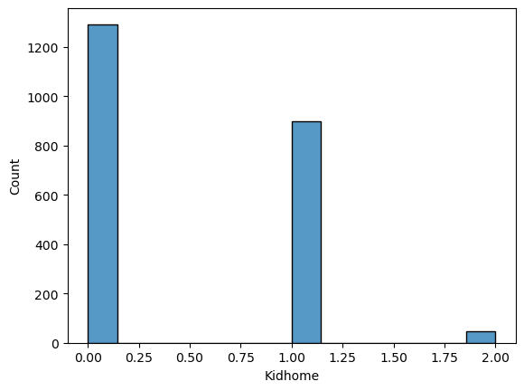

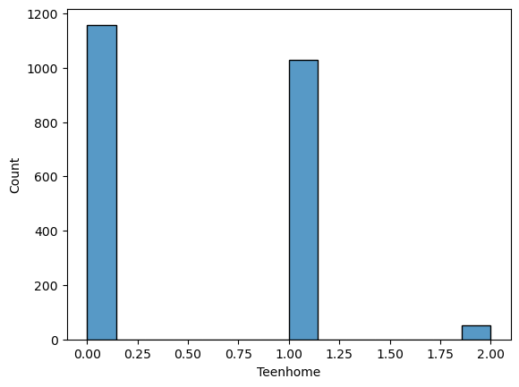

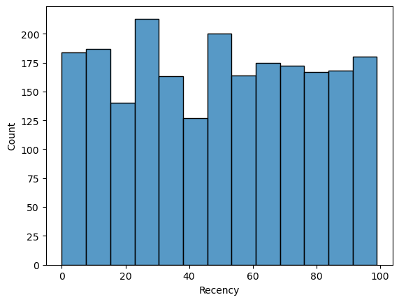

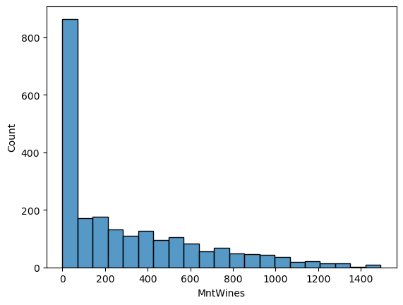

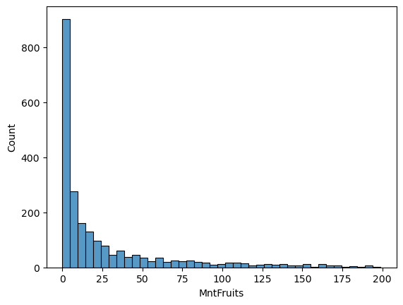

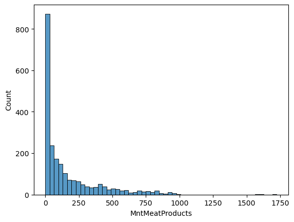

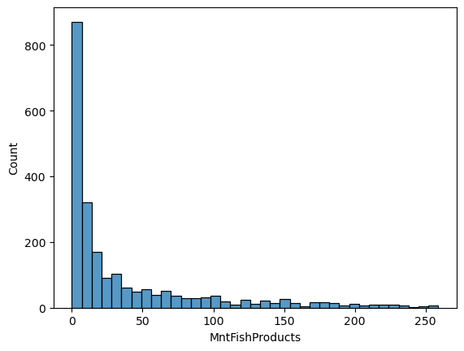

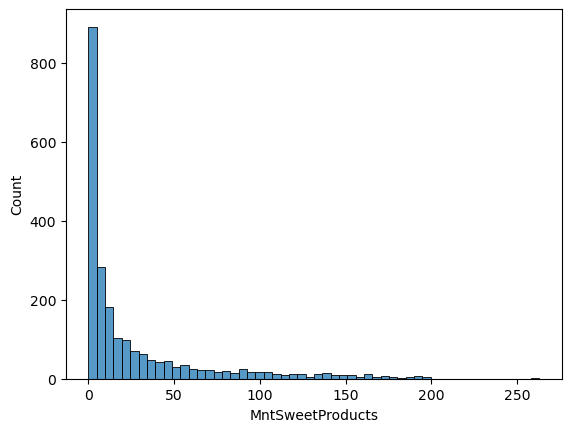

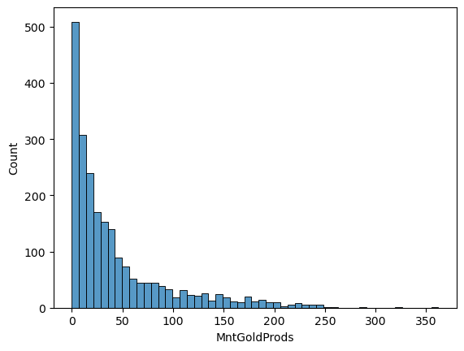

[1 more figures not shown]

```python
import seaborn as sns
import matplotlib.pyplot as plt

# een histogram toont het **aantal** regels uit een kolom dat binnen een bepaalde range valt.

# Snel maar niet zo mooi:

num_data.hist(figsize=(20,10))
plt.show()

#Mooier (mag ook zonder for loop, maar veel werk):
for col in num_data.columns:
    sns.histplot(data=num_data, x=col)
    plt.show()

#Year_Birth: benadert een normale verdeling. Vreemde outliers rond 1900 en 1890.
#Income: Ook grotendeels normaal verdeeld, maar outliers naar boven toe en 1 extreme outlier.
#KidHome: De meeste klanten hebben geen kinderen. Als ze kinderen hebben dan gaat het om slechts 1 kind.
    # Met een paar uitzonderingen met 2 kinderen. De klanten van dit bedrijf lijken af te wijken van de "normale" bevolking.
#TeenHome: De meeste klanten hebben geen tieners. Als ze die hebben dan gaat het om slechts 1 kind.
    # Met een paar uitzonderingen met 2 kinderen. De klanten van dit bedrijf lijken af te wijken van de "normale" bevolking.
# Recency: een vlakke verdeling (niet normaal verdeeld)
# Mnt-kolommen: allemaal scheef verdeeld. De meeste klanten geven hier weinig tot niets aan uit. Kleine groepen geven hieraan iets tot veel uit.
    # Verder valt op dat wines en meat doorlopen tot boven de 1000 op de x-as. Hieraan wordt de door kleine groepen veel uitgegeven.
```

### 5 Verdelingen: Boxplots

Een andere manier om naar verdelingen te kijken is met boxplots.

- Toon een boxplot van de Year_Birth kolom.
- Leg uit wat je hieruit afleest. Gebruik hierbij de volgende termen:
  - kwartiel en kwartielafstand
  - Mediaan
  - Snorharen (whiskers)
  - Outliers

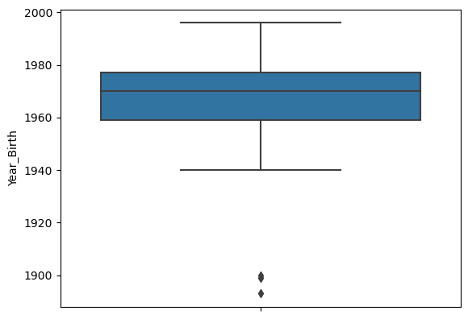

```python
sns.boxplot(data=num_data, y='Year_Birth')
plt.show()
# 25% percentiel = 1e kwartiel = 25% van de waardes zijn kleiner: ligt net onder 1960 (schatting: 1959)
# 75% percentiel = 3e kwartiel = 75% van de waardes zijn kleiner: ligt onder 1980 (schatting: 1977)
# kwartielafstand = inter quartile range = IQR: 1977 - 1959 = 18
# whiskers = snorharen: bovenste (upper whisker) ligt rond 1998, onderste (lower whisker) ligt rond 1940.
# outliers zijn getallen rond en onder 1900.
```

Bereken de volgende waardes van 'Year_Birth' (**hint**: gebruik o.a. .quantile()):

- 1e kwartiel
- 3e kwartiel
- kwartielafstand
- upper whisker
- lower whisker

```python
q25 = data['Year_Birth'].quantile(.25)
q75 = data['Year_Birth'].quantile(.75)
iqr = q75 - q25
print(q25, q75, iqr)

# calculate potential lower_whisker:
potential_lower_whisker = max(min(data['Year_Birth']), q25 - 1.5 * iqr)
#determine numbers between q25 and potential lower whisker
betw_q25_and_lw = data['Year_Birth'][(data['Year_Birth'] <= q25) & (data['Year_Birth'] >= potential_lower_whisker) ]
#if potential lower whisker not in dataset, the lowest number of this range is picked.
lower_whisker = min(betw_q25_and_lw)
# calculate potential upper_whisker:
potential_upper_whisker = min(max(data['Year_Birth']), q75 + 1.5 * iqr)
#determine numbers between q75 and potential upper whisker
betw_q75_and_uw = data['Year_Birth'][(data['Year_Birth'] >= q75) & (data['Year_Birth'] <= potential_upper_whisker) ]
#if potential upper whisker not in dataset, the highest number of this range is picked.
upper_whisker = max(betw_q75_and_uw)
print(lower_whisker, upper_whisker)
```

```
1959.0 1977.0 18.0
1940 1996
```

- Toon de boxplots van alle relevante kolommen
- Beschrijf wat je opvalt.

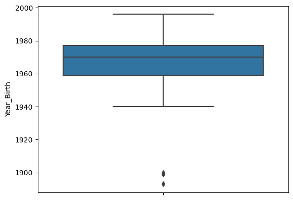

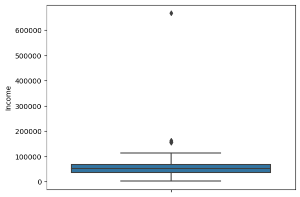

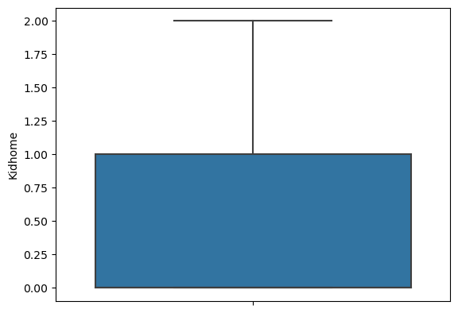

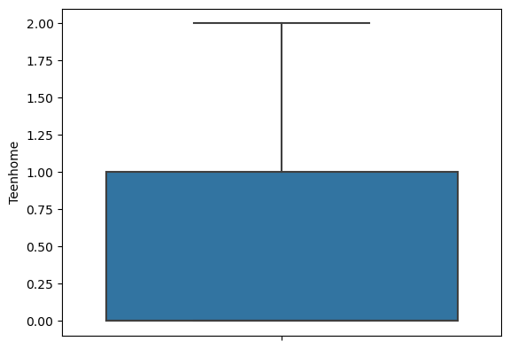

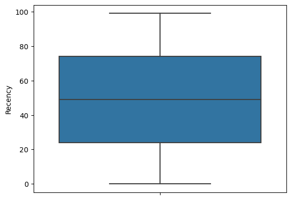

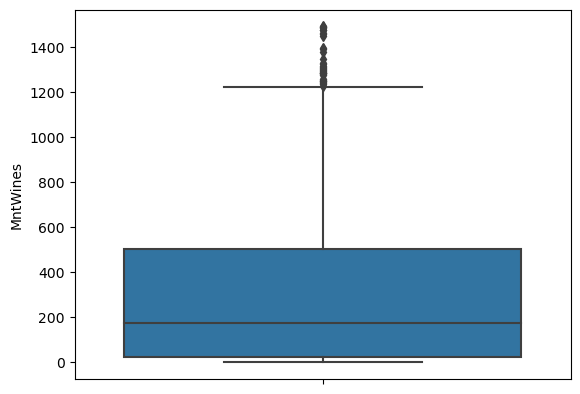

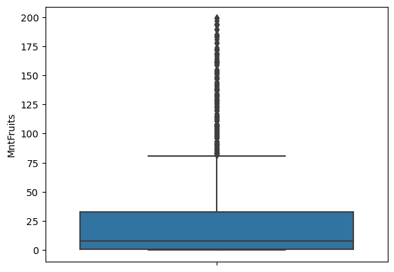

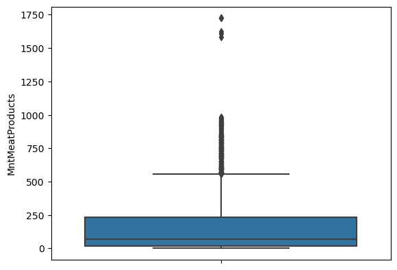

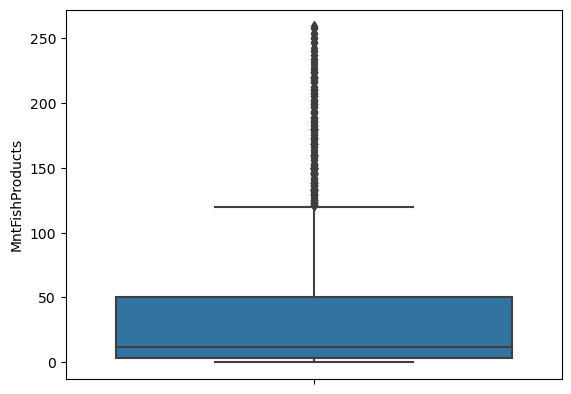

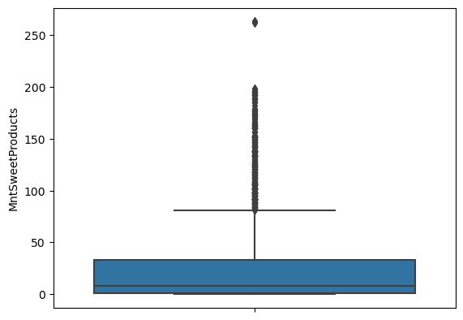

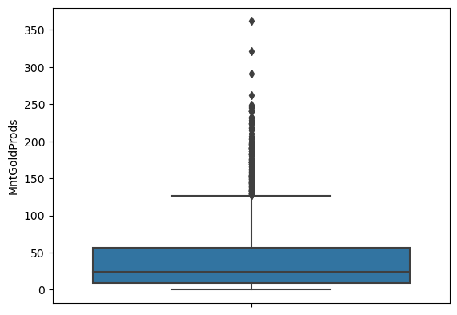

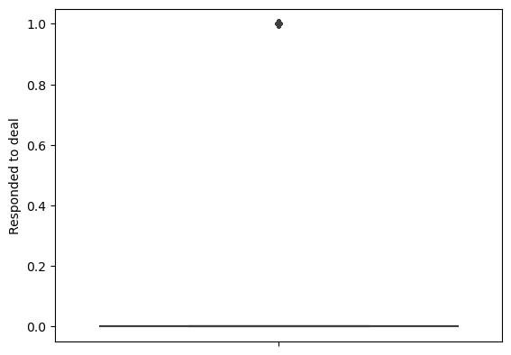

```python
for col in num_data.columns:
    sns.boxplot(data=num_data, y=col)
    plt.show()

# Year_Birth: 3 outliers aan de onderkant
# Income: een paar outliers aan de bovenkant waarvan 1 extreem hoog.
# Boxplots van KidHome en TeenHome geven weinig info. Niet nuttig.
# Recency: heel symmetrisch (past bij vlakke verdeling)
# Mnt-kolommen veel uitschieters naar boven, boxes zijn klein, snorharen vooral aan de bovenkant.
# conclusie: histogrammen en boxplots laten hetzelfde zien, maar op een andere manier.
```